# Lab Day 2a: EFA and CFA

Today’s lab meeting consists of three exercises: In exercise 1, you replicate what was done in the lecture with respect to the basics of factor analysis. Exercises 2 and 3 are additional exercises on EFA and CFA, respectively.

Practical information:

- All the data and other files for these exercises can be found at the LLL platform.Make sure to unzip the files. The folder containing these files will be your working directory.
- Solutions to the exercises can be found in the Solutions folder. We provided R scripts for doing each of the exercises with `lavaan`

### Exercise 1: Replicate Sapi results from the lecture

The file Sapi.txt contains the data that was used to conduct the EFA and CFA as presented in the lecture. Try to replicate the following input files and/or results of today’s presentation and see what happens to the results.

Note: To prevent issues, make sure you specify -999 as missing data

#### 1.1 Reflective (confirmatory) Factor Model

**a. Inspect the correlations for the items of interest: Q77 Q84 Q170 Q196. Why would you inspect these before doing a CFA?**

**Click to show answers**

**Getting started:**

To get started, the `lavaan` package is available on CRAN and can be installed by running the code below in the R (studio) console:

```r
# install this package first (once)
if (!require("lavaan")) install.packages("lavaan", dependencies = TRUE)
```

You can check if the installation was successful by typing:

```r
library(lavaan)
```

A start-up message will be displayed showing the version number (always report this in your papers) and a reminder that this is free software. If you see this message, you are ready to start.

To load the data into the R environment, run the following to load the data:

Note: The data file needs to be in the same folder location that you are working in. Otherwise, you can tell R where to find it by copying the folder path.

```r
data_sapi <- read.table("Sapi.txt", header = T)
```

Now the data is loaded, you need to find missing values and set them to “NA”. In this dataset, “-999” denotes a missing case. If you ‘forget’ to tell R this, these values will be treated as being observed.

```r
data_sapi[sapply(data_sapi, function(x) as.character(x) %in% c("-999") )] <- NA
```

**Get item correlations:**

Before we specify any models we need to check the correlations among the items of interest. These items are: *Q77 Q84 Q170 Q196*. The correlation table gives the correlations between pairs of items, that is, the standardized covariances between a pair of items, equivalent to running covariances on the Z-scores of each item.

Bear in mind that the correlation for Items X and Y is the same as for Y and X. The diagonal elements are always one because an item is always perfectly correlated with itself. Recall that the magnitude of a correlation is determined by the absolute value of the correlation.

From this table, we see that the items have magnitudes ranging from 0.2 to 0.6. In psychology and the social sciences, the magnitude of correlations above 0.30 is considered a medium effect size. Due to relatively high correlations among many of the items these data would be a good candidate for factor analysis.

The goal of factor analysis is to model the interrelationships between many items with fewer unobserved or latent variables.

```r
# package for correlations
if (!require("Hmisc")) install.packages("Hmisc", dependencies = TRUE)
library(Hmisc)

# rcorr() accepts matrices only
res <- rcorr(as.matrix(data_sapi[, c(9:10, 12:13)]))
# Correlation matrix (rounded to 3 decimals)
round(res$r, 3)
```

```
##        Q77   Q84  Q170  Q196
## Q77  1.000 0.487 0.323 0.534
## Q84  0.487 1.000 0.204 0.353
## Q170 0.323 0.204 1.000 0.449
## Q196 0.534 0.353 0.449 1.000
```

**b. Replicate the results for the extraversion model presented in the lecture slides. One can use the function `lavaan()` but also the function `cfa()` for this (the solutions use the latter).**

**Click to show answers**

With factor analysis you can determine the extent to which items designed to measure a particular factor (in this case extraversion) actually do so. It is the ‘true’ correlation between an indicator and a factor. So, every factor (in this case Extraversion) is a weighted sum of the items.

In `lavaan`, the operator for the latent variable definition is: “=~”. This, thus, denotes ‘is measured by’ (cf., BY in Mplus).

Recall that =~ represents the indicator equation where the latent variable is on the left and the indicators (or observed variables), separated by + signs, are to the right the symbol. Note that, for the latter, the names come from the data set.

**Specify the model:**

```r
# Model statement: one factor, four items, default marker method
model.CFA <- 'Extraversion =~ Q77 + Q84 + Q170 + Q196'
```

**Fit the model:**

This code runs a confirmatory factor analysis using the `cfa()` function, which is actually a wrapper for the `lavaan()` function (we used on Day 1).

```r
# Fit the model:
fit_CFA <- cfa(model.CFA, data=data_sapi,
               missing='fiml', fixed.x=F) # Specify FIML
```

**Get the model summary:**

Inspect the model summary. This requests textual output, listing for example:

- the estimator used
- the number of free parameters
- the test statistic
- estimated means
- loadings
- variances

```r
# Output
summary(fit_CFA)
```

```
## lavaan 0.6-10 ended normally after 25 iterations
##
##   Estimator                                         ML
##   Optimization method                           NLMINB
##   Number of model parameters                        12
##
##   Number of observations                          1000
##   Number of missing patterns                         5
##
## Model Test User Model:
##
##   Test statistic                                57.075
##   Degrees of freedom                                 2
##   P-value (Chi-square)                           0.000
##
## Parameter Estimates:
##
##   Standard errors                             Standard
##   Information                                 Observed
##   Observed information based on                Hessian
##
## Latent Variables:
##                    Estimate  Std.Err  z-value  P(>|z|)
##   Extraversion =~
##     Q77               1.000
##     Q84               0.708    0.047   15.213    0.000
##     Q170              0.567    0.052   10.996    0.000
##     Q196              0.742    0.052   14.179    0.000
##
## Intercepts:
##                    Estimate  Std.Err  z-value  P(>|z|)
##    .Q77               3.571    0.034  103.670    0.000
##    .Q84               3.224    0.033   96.473    0.000
##    .Q170              3.947    0.031  127.448    0.000
##    .Q196              3.800    0.028  137.529    0.000
##     Extraversion      0.000
##
## Variances:
##                    Estimate  Std.Err  z-value  P(>|z|)
##    .Q77               0.486    0.048   10.217    0.000
##    .Q84               0.762    0.041   18.556    0.000
##    .Q170              0.730    0.038   19.283    0.000
##    .Q196              0.374    0.030   12.630    0.000
##     Extraversion      0.696    0.064   10.825    0.000
```

```r
# Alternative
summary(fit_CFA, fit.measures=TRUE)
```

```
## lavaan 0.6-10 ended normally after 25 iterations
##
##   Estimator                                         ML
##   Optimization method                           NLMINB
##   Number of model parameters                        12
##
##   Number of observations                          1000
##   Number of missing patterns                         5
##
## Model Test User Model:
##
##   Test statistic                                57.075
##   Degrees of freedom                                 2
##   P-value (Chi-square)                           0.000
##
## Model Test Baseline Model:
##
##   Test statistic                               844.837
##   Degrees of freedom                                 6
##   P-value                                        0.000
##
## User Model versus Baseline Model:
##
##   Comparative Fit Index (CFI)                    0.934
##   Tucker-Lewis Index (TLI)                       0.803
##
## Loglikelihood and Information Criteria:
##
##   Loglikelihood user model (H0)              -5214.162
##   Loglikelihood unrestricted model (H1)      -5185.625
##
##   Akaike (AIC)                               10452.325
##   Bayesian (BIC)                             10511.218
##   Sample-size adjusted Bayesian (BIC)        10473.105
##
## Root Mean Square Error of Approximation:
##
##   RMSEA                                          0.166
##   90 Percent confidence interval - lower         0.130
##   90 Percent confidence interval - upper         0.204
```

[output cut: 20 more lines]

```
## Intercepts:
##                    Estimate  Std.Err  z-value  P(>|z|)
##    .Q77               3.571    0.034  103.670    0.000
##    .Q84               3.224    0.033   96.473    0.000
##    .Q170              3.947    0.031  127.448    0.000
##    .Q196              3.800    0.028  137.529    0.000
##     Extraversion      0.000
##
## Variances:
##                    Estimate  Std.Err  z-value  P(>|z|)
##    .Q77               0.486    0.048   10.217    0.000
##    .Q84               0.762    0.041   18.556    0.000
##    .Q170              0.730    0.038   19.283    0.000
##    .Q196              0.374    0.030   12.630    0.000
##     Extraversion      0.696    0.064   10.825    0.000
```

#### 1.2 Scaling your latent variable

**a. Is the latent variable scaled via the variance of the factor (reference groupscaling) pr via the factor loadings (marker variable scaling)?**

*Hint: Use the function `lavInspect()` to obtain insight.*

**Click to show answers**

```r
# Technical output - comparable to TECH1 in Mplus
lavInspect(fit_CFA)
```

```
## $lambda
##      Extrvr
## Q77       0
## Q84       1
## Q170      2
## Q196      3
##
## $theta
##      Q77 Q84 Q170 Q196
## Q77  4
## Q84  0   5
## Q170 0   0   6
## Q196 0   0   0    7
##
## $psi
##              Extrvr
## Extraversion 8
##
## $nu
##      intrcp
## Q77       9
## Q84      10
## Q170     11
## Q196     12
##
## $alpha
##              intrcp
## Extraversion      0
```

From this one can see what type of scaling is used. Because of:

- $lambda
- Extraversion
- Q77 0
- Q84 1
- Q170 2
- Q196 3

One can see that the first factor loading is fixed (to 1). Hence, the marker variable method is used.

**b. Adjust the model so that you can scale in the other way. That is, if part a) was scaled by fixing a factor loadings to 1 then free this factor loading and fix the factor variance to 1; If part a) was scaled by fixing the factor variance to 1, then free the factor variance and fix one of the factor loadings to 1.**

**Click to show answers**

By default, `lavaan` chooses the marker method. To use the ‘var std’ method (i.e., reference group scaling), one should make use of the following:

- To free a parameter, put ’NA*’ in front of the parameter to be freed:
- The syntax ’NA*Q77’ frees the loading of the first item because by default marker method fixes it to one.
- To fix a parameter to 1, put ’1*’ in front of the parameter to be fixed.

The syntax Extraversion ~~ 1*Extraversion fixes the variance of the factor Extraversion to one.

```r
# Specify model:
model.CFA_RefGr <- '
 Extraversion =~ NA*Q77 + Q84 + Q170 + Q196
 Extraversion ~~ 1*Extraversion
'
# Fit model:
fit_CFA_RefGr <- cfa(model.CFA_RefGr, data=data_sapi,
               missing='fiml', fixed.x=F) # Specify FIML

# Get model summary:
summary(fit_CFA_RefGr)
```

```
## lavaan 0.6-10 ended normally after 21 iterations
##
##   Estimator                                         ML
##   Optimization method                           NLMINB
##   Number of model parameters                        12
##
##   Number of observations                          1000
##   Number of missing patterns                         5
##
## Model Test User Model:
##
##   Test statistic                                57.075
##   Degrees of freedom                                 2
##   P-value (Chi-square)                           0.000
##
## Parameter Estimates:
##
##   Standard errors                             Standard
##   Information                                 Observed
##   Observed information based on                Hessian
##
## Latent Variables:
##                    Estimate  Std.Err  z-value  P(>|z|)
##   Extraversion =~
##     Q77               0.835    0.039   21.651    0.000
##     Q84               0.591    0.036   16.294    0.000
##     Q170              0.473    0.035   13.361    0.000
##     Q196              0.619    0.031   20.055    0.000
##
## Intercepts:
##                    Estimate  Std.Err  z-value  P(>|z|)
##    .Q77               3.571    0.034  103.670    0.000
##    .Q84               3.224    0.033   96.473    0.000
##    .Q170              3.947    0.031  127.448    0.000
##    .Q196              3.800    0.028  137.529    0.000
##     Extraversion      0.000
##
## Variances:
##                    Estimate  Std.Err  z-value  P(>|z|)
##     Extraversion      1.000
##    .Q77               0.486    0.048   10.217    0.000
##    .Q84               0.762    0.041   18.556    0.000
##    .Q170              0.730    0.038   19.283    0.000
##    .Q196              0.374    0.030   12.630    0.000
```

Alternatively you can use std.lv=TRUE and obtain the same results.Note that the chi-square fit results are exactly the same across the models, as will be explained below. That is why both solutions can be asked for by using ‘std.lv=TRUE’.

For better interpretation of the factor loadings, you would request the standardized solutions. Therefore, one may want to request the summary of the marker method but also specify that standardized=TRUE;

Then you obtain both results:

```r
summary(fit_CFA, standardized=TRUE)
```

```
## lavaan 0.6-10 ended normally after 25 iterations
##
##   Estimator                                         ML
##   Optimization method                           NLMINB
##   Number of model parameters                        12
##
##   Number of observations                          1000
##   Number of missing patterns                         5
##
## Model Test User Model:
##
##   Test statistic                                57.075
##   Degrees of freedom                                 2
##   P-value (Chi-square)                           0.000
##
## Parameter Estimates:
##
##   Standard errors                             Standard
##   Information                                 Observed
##   Observed information based on                Hessian
##
## Latent Variables:
##                    Estimate  Std.Err  z-value  P(>|z|)   Std.lv  Std.all
##   Extraversion =~
##     Q77               1.000                               0.835    0.767
##     Q84               0.708    0.047   15.213    0.000    0.591    0.560
##     Q170              0.567    0.052   10.996    0.000    0.473    0.485
##     Q196              0.742    0.052   14.179    0.000    0.619    0.712
##
## Intercepts:
##                    Estimate  Std.Err  z-value  P(>|z|)   Std.lv  Std.all
##    .Q77               3.571    0.034  103.670    0.000    3.571    3.283
##    .Q84               3.224    0.033   96.473    0.000    3.224    3.059
##    .Q170              3.947    0.031  127.448    0.000    3.947    4.040
##    .Q196              3.800    0.028  137.529    0.000    3.800    4.366
##     Extraversion      0.000                               0.000    0.000
##
## Variances:
##                    Estimate  Std.Err  z-value  P(>|z|)   Std.lv  Std.all
##    .Q77               0.486    0.048   10.217    0.000    0.486    0.411
##    .Q84               0.762    0.041   18.556    0.000    0.762    0.686
##    .Q170              0.730    0.038   19.283    0.000    0.730    0.765
##    .Q196              0.374    0.030   12.630    0.000    0.374    0.494
##     Extraversion      0.696    0.064   10.825    0.000    1.000    1.000
```

Now, there are two additional columns: Std.lv and Std.all (cf. STD and STDYX in Mplus).

- **Std.all:** standardizes the factor loadings by the standard deviation of both the predictor (the factor, X) and the outcome (the item, Y).
- **Std.lv:** standardizes the factor loadings by the predictor (the factor, X).

Comparing the two: The loadings and variance of the factors are different but the residual variances are the same.

**c. Bonus: Scale via the factor loadings again, but now fix the factor loading of Q196 to 1, and free the factor loading that was previously fixed to 1.**

Based on your results what do you notice about the chi-square, degrees of freedom, p-values, factor loadings, and factor variance for the different methods?

**Click to show answers**

**Fix other factor loadings:**

In case you want, in the Marker variable method, another factor loading to be 1, say, the last one:

Remember:

- 1* fixes parameter or loading to one
- NA* frees parameter or loading (useful to override default marker method)

```r
# Model statement:
model.CFA_last <- '
 Extraversion =~ NA*Q77 + Q84 + Q170 + 1*Q196
'

# Fit model:
fit_CFA_last <- cfa(model.CFA_last, data=data_sapi,
                     missing='fiml', fixed.x=F) # Specify FIML

# Model summary:
summary(fit_CFA_last)
```

```
## lavaan 0.6-10 ended normally after 28 iterations
##
##   Estimator                                         ML
##   Optimization method                           NLMINB
##   Number of model parameters                        12
##
##   Number of observations                          1000
##   Number of missing patterns                         5
##
## Model Test User Model:
##
##   Test statistic                                57.075
##   Degrees of freedom                                 2
##   P-value (Chi-square)                           0.000
##
## Parameter Estimates:
##
##   Standard errors                             Standard
##   Information                                 Observed
##   Observed information based on                Hessian
##
## Latent Variables:
##                    Estimate  Std.Err  z-value  P(>|z|)
##   Extraversion =~
##     Q77               1.347    0.095   14.179    0.000
##     Q84               0.953    0.075   12.673    0.000
##     Q170              0.764    0.058   13.163    0.000
##     Q196              1.000
##
## Intercepts:
##                    Estimate  Std.Err  z-value  P(>|z|)
##    .Q77               3.571    0.034  103.670    0.000
##    .Q84               3.224    0.033   96.473    0.000
##    .Q170              3.947    0.031  127.448    0.000
##    .Q196              3.800    0.028  137.529    0.000
##     Extraversion      0.000
##
## Variances:
##                    Estimate  Std.Err  z-value  P(>|z|)
##    .Q77               0.486    0.048   10.217    0.000
##    .Q84               0.762    0.041   18.556    0.000
##    .Q170              0.730    0.038   19.283    0.000
##    .Q196              0.374    0.030   12.630    0.000
##     Extraversion      0.384    0.038   10.027    0.000
```

The first thing you may notice is that all chi-square fit results are exactly the same across the models. This is because the different ways of scaling all result in equivalent statistical models. You don’t estimate anything more or less with any of the three scaling methods.

The second thing you may notice is that the values of the loadings have changed. However, loadings that are relatively large (or small) in one model, are also relatively large (or small) in the other models.For example, in each model, the loading for Q77 is ~1.4 times as large as the loading of Q84.

The take home message is that it does not matter how you scale, the information that you get is the same.

#### 1.3 Model fit

**a. Inspect the model fit. Focus on the CFI, TLI, RMSEA, and SRMR. You can use `summary()` or `fitMeasures()`.**

**Click to show answers**

Four measures of model fit are:

1. Model chi-square is the chi-square statistic obtained from the maximum likelihood statistic.
   - (in `lavaan`: ‘the Test Statistic for the Model Test User Model’)
2. CFI is the Comparative Fit Index.
   - Values can range between 0 and 1
   - (values greater than 0.90, conservatively 0.95 indicate good fit)
3. TLI Tucker Lewis Index which also ranges between 0 and 1
   - Values greater than 0.90 indicating good fit.
   - (if it’s greater than 1 it should be rounded to 1)
   - If the CFI and TLI are less than one, the CFI is always greater than the TLI.
4. RMSEA is the root mean square error of approximation.
   - In `lavaan`, you also obtain a p-value of close fit, that the RMSEA < 0.05.
   - If you reject the model, it means your model is not a close fitting model.

You can obtain these using the following code:

```r
# One method:
summary(fit_CFA, fit.measures=TRUE) # many model fit measures
```

```
## lavaan 0.6-10 ended normally after 25 iterations
##
##   Estimator                                         ML
##   Optimization method                           NLMINB
##   Number of model parameters                        12
##
##   Number of observations                          1000
##   Number of missing patterns                         5
##
## Model Test User Model:
##
##   Test statistic                                57.075
##   Degrees of freedom                                 2
##   P-value (Chi-square)                           0.000
##
## Model Test Baseline Model:
##
##   Test statistic                               844.837
##   Degrees of freedom                                 6
##   P-value                                        0.000
##
## User Model versus Baseline Model:
##
##   Comparative Fit Index (CFI)                    0.934
##   Tucker-Lewis Index (TLI)                       0.803
##
## Loglikelihood and Information Criteria:
##
##   Loglikelihood user model (H0)              -5214.162
##   Loglikelihood unrestricted model (H1)      -5185.625
##
##   Akaike (AIC)                               10452.325
##   Bayesian (BIC)                             10511.218
##   Sample-size adjusted Bayesian (BIC)        10473.105
##
## Root Mean Square Error of Approximation:
##
##   RMSEA                                          0.166
##   90 Percent confidence interval - lower         0.130
##   90 Percent confidence interval - upper         0.204
```

[output cut: 20 more lines]

```
## Intercepts:
##                    Estimate  Std.Err  z-value  P(>|z|)
##    .Q77               3.571    0.034  103.670    0.000
##    .Q84               3.224    0.033   96.473    0.000
##    .Q170              3.947    0.031  127.448    0.000
##    .Q196              3.800    0.028  137.529    0.000
##     Extraversion      0.000
##
## Variances:
##                    Estimate  Std.Err  z-value  P(>|z|)
##    .Q77               0.486    0.048   10.217    0.000
##    .Q84               0.762    0.041   18.556    0.000
##    .Q170              0.730    0.038   19.283    0.000
##    .Q196              0.374    0.030   12.630    0.000
##     Extraversion      0.696    0.064   10.825    0.000
```

```r
# Alternative method:
fitMeasures(fit_CFA) # many model fit measures
```

```
##                npar                fmin               chisq                  df
##              12.000               0.029              57.075               2.000
##              pvalue      baseline.chisq         baseline.df     baseline.pvalue
##               0.000             844.837               6.000               0.000
##                 cfi                 tli                nnfi                 rfi
##               0.934               0.803               0.803               0.797
##                 nfi                pnfi                 ifi                 rni
##               0.932               0.311               0.935               0.934
##                logl   unrestricted.logl                 aic                 bic
##           -5214.162           -5185.625           10452.325           10511.218
##              ntotal                bic2               rmsea      rmsea.ci.lower
##            1000.000           10473.105               0.166               0.130
##      rmsea.ci.upper        rmsea.pvalue                 rmr          rmr_nomean
##               0.204               0.000               0.039               0.046
##                srmr        srmr_bentler srmr_bentler_nomean                crmr
##               0.040               0.040               0.048               0.048
##         crmr_nomean          srmr_mplus   srmr_mplus_nomean               cn_05
##               0.062               0.040               0.048             105.975
##               cn_01                 gfi                agfi                pgfi
##             162.372               0.998               0.985               0.143
##                 mfi                ecvi
##               0.973               0.081
```

Notes:

- Failing to reject the model is good for the model at hand because it implies failing to disprove that the model is bad. Here, we reject the null hypothesis that the model fits the data.
- It is well documented in CFA and SEM literature that the chi-square is often overly sensitive in model testing especially for large samples.
- David Kenny states that for models with 75 to 200 cases chi-square is a reasonable measure of fit; but for 400 cases or more it is nearly almost always significant.Our sample size is 1000.
- Kline (2016) notes the N:q rule, which states that
  - the sample size (N) should be determined by the number of parameters in your model (q)
  - the recommended ratio is 20:1
  - this means that if you have 12 parameters, you should have N=240
  - a sample size less than 100 is almost always untenable according to Kline
- The larger the chi-square value the larger the difference between the sample implied covariance matrix and the sample observed one, and the more likely you will reject your model.

**Request specific fit measures:**

```r
# Another alternative:
fitMeasures(fit_CFA, c("cfi", "tli", "rmsea","srmr"))
```

```
##   cfi   tli rmsea  srmr
## 0.934 0.803 0.166 0.040
```

- For CFI, value slightly below the recommended cut-off criterion of 0.97/0.95.
- For TLI, value below the recommended cut-off criterion of 0.97/0.95.
- The RMSEA is above the cut-off of 0.05.
- The SRMR points to a good model fit (SRMR < 0.08).
- Overall, the model does not seem to fit well.

**Plotting the results:**

Try to plot the results of a fit object using `lavaanPlot()`, `tidySEM()`, or `semPlot()`.

```r
# Install this package first (once):
if (!require("lavaanPlot")) install.packages("lavaanPlot")
library(lavaanPlot)

# Plot:
lavaanPlot(model = fit_CFA, node_options = list(shape = "box", fontname = "Helvetica"),
           edge_options = list(color = "grey"), coefs = T, stand = T, covs = T)
```

[figure not shown]

```r
# Alternative:
if (!require("tidySEM")) install.packages("tidySEM") # install this package first (once)
library(tidySEM)
graph_sem(fit_CFA)
```

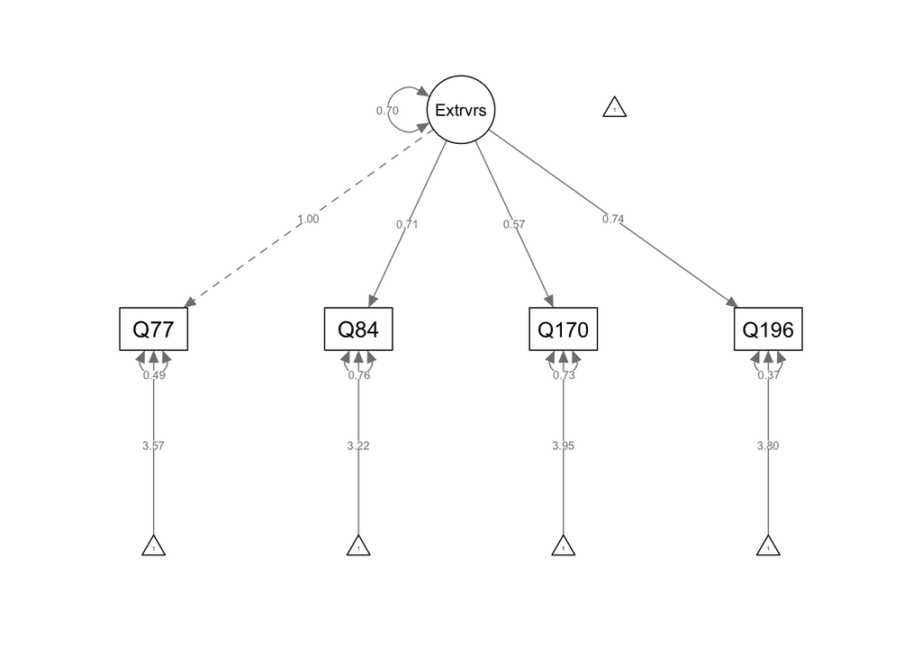

```r
# Another alternative:
if (!require("semPlot")) install.packages("semPlot") # install this package first (once)
library(semPlot)
semPaths(fit_CFA, "par", weighted = FALSE, nCharNodes = 7, shapeMan = "rectangle",
         sizeMan = 8, sizeMan2 = 5)
```

#### 1.4 Test equality of factor loadings

Based on the factor loadings, items do not seem to be equally reflective of Extraversion, except for Q84 and Q196. To improve the fit of the model, one can test whether these factor loadings are equal (resulting in estimating less parameters). One can use a Wald test to test whether two factor loadings can be considered equal.

**a. Test whether the factor loadings of Q84 and Q196 are the same.**

*Hint: For a `lavaan` object (with label names!) one can do this with lavTestWald(fit, constrains = ‘insert equality restriction’).*

**Click to show answers**

**Specify the model:**

```r
# Specify model:
model.CFA_equal <- '
 # model with labeled parameters
 Extraversion =~ Q77 + a*Q84 + Q170 + b*Q196
'
```

**Fit the model:**

```r
# Fit model:
fit_CFA_equal <- cfa(model.CFA_equal, data=data_sapi,
                     missing='fiml', fixed.x=F) # Specify FIML
```

**Conduct the Wald test:**

```r
# Wald test
lavTestWald(fit_CFA_equal, constraints = 'a == b')
```

```
## $stat
## [1] 0.3619674
##
## $df
## [1] 1
##
## $p.value
## [1] 0.5474156
##
## $se
## [1] "standard"
```

**b. What does the test imply?**

**Click to show answers**

Wald test with df=1 is 0.3619674, p = 0.5474156. Thus, we do not reject the null that the two loadings are equal. Hence, we conclude that there is no evidence for a difference between a and b.

In case one wants the model results for which the loadings are the same:

```r
# Specify model:
model.CFA_equal <- '
 # model with labeled parameters
 Extraversion =~ Q77 + a*Q84 + Q170 + b*Q196
 #
 # constraints
 a == b
'
# Note: a* labels the parameter ‘a’, used for model constraints.

# Fit model:
fit_CFA_equal <- cfa(model.CFA_equal, data=data_sapi,
                     missing='fiml', fixed.x=F) # Specify FIML

# Model summary:
summary(fit_CFA_equal, standardized=TRUE, fit.measures=TRUE)
```

```
## lavaan 0.6-10 ended normally after 24 iterations
##
##   Estimator                                         ML
##   Optimization method                           NLMINB
##   Number of model parameters                        12
##   Number of equality constraints                     1
##
##   Number of observations                          1000
##   Number of missing patterns                         5
##
## Model Test User Model:
##
##   Test statistic                                57.448
##   Degrees of freedom                                 3
##   P-value (Chi-square)                           0.000
##
## Model Test Baseline Model:
##
##   Test statistic                               844.837
##   Degrees of freedom                                 6
##   P-value                                        0.000
##
## User Model versus Baseline Model:
##
##   Comparative Fit Index (CFI)                    0.935
##   Tucker-Lewis Index (TLI)                       0.870
##
## Loglikelihood and Information Criteria:
##
##   Loglikelihood user model (H0)              -5214.349
##   Loglikelihood unrestricted model (H1)      -5185.625
##
##   Akaike (AIC)                               10450.697
##   Bayesian (BIC)                             10504.683
##   Sample-size adjusted Bayesian (BIC)        10469.746
##
## Root Mean Square Error of Approximation:
##
##   RMSEA                                          0.135
##   90 Percent confidence interval - lower         0.106
```

[output cut: 25 more lines]

```
##    .Q170              3.947    0.031  127.448    0.000    3.947    4.040
##    .Q196              3.800    0.028  138.079    0.000    3.800    4.384
##     Extraversion      0.000                               0.000    0.000
##
## Variances:
##                    Estimate  Std.Err  z-value  P(>|z|)   Std.lv  Std.all
##    .Q77               0.476    0.044   10.737    0.000    0.476    0.403
##    .Q84               0.754    0.039   19.523    0.000    0.754    0.672
##    .Q170              0.734    0.037   19.637    0.000    0.734    0.769
##    .Q196              0.383    0.026   14.967    0.000    0.383    0.509
##     Extraversion      0.706    0.062   11.346    0.000    1.000    1.000
##
## Constraints:
##                                                |Slack|
##     a - (b)                                      0.000
```

```r
fitMeasures(fit_CFA_equal, c("cfi", "tli", "rmsea","srmr"))
```

```
##   cfi   tli rmsea  srmr
## 0.935 0.870 0.135 0.042
```

The measures did improve, but the model still does not fit well.

#### 1.5 EFA vs CFA

**a. Specify and run the two-factor exploratory factor model (EFA) and two-factor CFA, as was shown in the lecture slides.**

**Click to show answers**

**Get the item correlations:**

```r
# Two-factor EFA versus CFA:

# Correlations for the items of interest: Q44 Q63 Q76 Q77 Q84 Q98 Q170 Q196
res <- rcorr(as.matrix(data_sapi[, c(6:13)])) # rcorr() accepts matrices only
# Correlation matrix (rounded to 3 decimals)
round(res$r, 3)
```

```
##        Q44   Q63   Q76   Q77   Q84   Q98  Q170  Q196
## Q44  1.000 0.309 0.296 0.136 0.179 0.264 0.173 0.181
## Q63  0.309 1.000 0.290 0.275 0.224 0.358 0.198 0.292
## Q76  0.296 0.290 1.000 0.259 0.268 0.298 0.197 0.241
## Q77  0.136 0.275 0.259 1.000 0.487 0.285 0.323 0.534
## Q84  0.179 0.224 0.268 0.487 1.000 0.353 0.204 0.353
## Q98  0.264 0.358 0.298 0.285 0.353 1.000 0.270 0.328
## Q170 0.173 0.198 0.197 0.323 0.204 0.270 1.000 0.449
## Q196 0.181 0.292 0.241 0.534 0.353 0.328 0.449 1.000
```

**Specify the two-factor EFA model:**

The efa(‘block1’) modifier indicates that the factors comprise an exploratory block (with the name block1) and thus that we do not exactly know the loading structure of the variables / items on these factors.

```r
# Specify two-factor EFA model:
model.2EFA <- "
 efa('block1')*Having fun  =~ Q77 + Q84 + Q170 + Q196 + Q44 + Q63 + Q76 + Q98
 efa('block1')*Being liked =~ Q77 + Q84 + Q170 + Q196 + Q44 + Q63 + Q76 + Q98
"
# Alternative:
model.2EFA <- "
efa('block1')*Having fun  + efa('block1')*Being liked =~
Q77 + Q84 + Q170 + Q196 + Q44 + Q63 + Q76 + Q98
"
```

**Fit the two-factor EFA model:**

```r
# Fit two-factor EFA model:
fit_2EFA <- cfa(model.2EFA, data=data_sapi,
                missing='fiml', fixed.x=F) # Specify FIML

# estimates the EFA model (releasing the residual variances and implying the EFA constraints) using the oblique geomin rotation.

# Model summary:
summary(fit_2EFA)
```

```
## lavaan 0.6-10 ended normally after 32 iterations
##
##   Estimator                                         ML
##   Optimization method                           NLMINB
##   Number of model parameters                        31
##
##   Rotation method                       GEOMIN OBLIQUE
##   Geomin epsilon                                 0.001
##   Rotation algorithm (rstarts)               GPA (100)
##   Standardized metric                             TRUE
##   Row weights                                     None
##
##   Number of observations                          1000
##   Number of missing patterns                        10
##
## Model Test User Model:
##
##   Test statistic                                89.155
##   Degrees of freedom                                13
##   P-value (Chi-square)                           0.000
##
## Parameter Estimates:
##
##   Standard errors                             Standard
##   Information                                 Observed
##   Observed information based on                Hessian
##
## Latent Variables:
##                        Estimate  Std.Err  z-value  P(>|z|)
##   Havingfun =~ block1
##     Q77                   0.884    0.042   21.269    0.000
##     Q84                   0.493    0.056    8.848    0.000
##     Q170                  0.336    0.073    4.608    0.000
##     Q196                  0.523    0.070    7.485    0.000
##     Q44                  -0.163    0.055   -2.975    0.003
##     Q63                   0.014    0.025    0.553    0.580
##     Q76                   0.031    0.056    0.563    0.573
##     Q98                   0.085    0.058    1.472    0.141
##   Beingliked =~ block1
##     Q77                  -0.028    0.021   -1.310    0.190
```

[output cut: 23 more lines]

```
##     Havingfun         0.000
##     Beingliked        0.000
##
## Variances:
##                    Estimate  Std.Err  z-value  P(>|z|)
##    .Q77               0.429    0.071    6.077    0.000
##    .Q84               0.727    0.038   19.260    0.000
##    .Q170              0.734    0.037   20.016    0.000
##    .Q196              0.398    0.030   13.201    0.000
##    .Q44               0.598    0.041   14.572    0.000
##    .Q63               0.816    0.050   16.405    0.000
##    .Q76               1.005    0.056   18.074    0.000
##    .Q98               0.489    0.029   16.612    0.000
##     Havingfun         1.000
##     Beingliked        1.000
```

```r
lavInspect(fit_2EFA)
```

```
## $lambda
##      Hvngfn Bnglkd
## Q77       1      0
## Q84       2      9
## Q170      3     10
## Q196      4     11
## Q44       5     12
## Q63       6     13
## Q76       7     14
## Q98       8     15
##
## $theta
##      Q77 Q84 Q170 Q196 Q44 Q63 Q76 Q98
## Q77  16
## Q84   0  17
## Q170  0   0  18
## Q196  0   0   0   19
## Q44   0   0   0    0   20
## Q63   0   0   0    0    0  21
## Q76   0   0   0    0    0   0  22
## Q98   0   0   0    0    0   0   0  23
##
## $psi
##            Hvngfn Bnglkd
## Havingfun  0
## Beingliked 0      0
##
## $nu
##      intrcp
## Q77      24
## Q84      25
## Q170     26
## Q196     27
## Q44      28
## Q63      29
## Q76      30
## Q98      31
##
## $alpha
##            intrcp
## Havingfun       0
## Beingliked      0
```

```r
# TO DO not same factor loadings as in Mplus + two warnings (not in Mplus)

# Specify two-factor CFA model:
model.2CFA <- "
 Having fun  =~ Q77 + Q84 + Q170 + Q196
 Being liked =~ Q44 + Q63 + Q76 + Q98
"
# Fit two-factor CFA model:
fit_2CFA <- cfa(model.2CFA, data=data_sapi,
                missing='fiml', fixed.x=F) # Specify FIML

# Model summary:
summary(fit_2CFA)
```

```
## lavaan 0.6-10 ended normally after 44 iterations
##
##   Estimator                                         ML
##   Optimization method                           NLMINB
##   Number of model parameters                        25
##
##   Number of observations                          1000
##   Number of missing patterns                        10
##
## Model Test User Model:
##
##   Test statistic                               124.170
##   Degrees of freedom                                19
##   P-value (Chi-square)                           0.000
##
## Parameter Estimates:
##
##   Standard errors                             Standard
##   Information                                 Observed
##   Observed information based on                Hessian
##
## Latent Variables:
##                    Estimate  Std.Err  z-value  P(>|z|)
##   Havingfun =~
##     Q77               1.000
##     Q84               0.763    0.049   15.710    0.000
##     Q170              0.617    0.049   12.649    0.000
##     Q196              0.784    0.046   17.150    0.000
##   Beingliked =~
##     Q44               1.000
##     Q63               1.534    0.144   10.637    0.000
##     Q76               1.444    0.143   10.134    0.000
##     Q98               1.268    0.122   10.354    0.000
##
## Covariances:
##                    Estimate  Std.Err  z-value  P(>|z|)
##   Havingfun ~~
##     Beingliked        0.231    0.024    9.669    0.000
##
## Intercepts:
```

[output cut: 9 more lines]

```
##     Havingfun         0.000
##     Beingliked        0.000
##
## Variances:
##                    Estimate  Std.Err  z-value  P(>|z|)
##    .Q77               0.546    0.039   14.035    0.000
##    .Q84               0.740    0.040   18.528    0.000
##    .Q170              0.712    0.036   19.747    0.000
##    .Q196              0.365    0.025   14.558    0.000
##    .Q44               0.668    0.034   19.554    0.000
##    .Q63               0.801    0.047   16.982    0.000
##    .Q76               1.005    0.054   18.544    0.000
##    .Q98               0.467    0.029   16.106    0.000
##     Havingfun         0.638    0.056   11.380    0.000
##     Beingliked        0.180    0.029    6.300    0.000
```

```r
lavInspect(fit_2CFA)
```

```
## $lambda
##      Hvngfn Bnglkd
## Q77       0      0
## Q84       1      0
## Q170      2      0
## Q196      3      0
## Q44       0      0
## Q63       0      4
## Q76       0      5
## Q98       0      6
##
## $theta
##      Q77 Q84 Q170 Q196 Q44 Q63 Q76 Q98
## Q77   7
## Q84   0   8
## Q170  0   0   9
## Q196  0   0   0   10
## Q44   0   0   0    0   11
## Q63   0   0   0    0    0  12
## Q76   0   0   0    0    0   0  13
## Q98   0   0   0    0    0   0   0  14
##
## $psi
##            Hvngfn Bnglkd
## Havingfun  15
## Beingliked 17     16
##
## $nu
##      intrcp
## Q77      18
## Q84      19
## Q170     20
## Q196     21
## Q44      22
## Q63      23
## Q76      24
## Q98      25
##
## $alpha
##            intrcp
## Havingfun       0
## Beingliked      0
```

### Exercise 2: EFA

#### 2.1 Use the data file popular_factor.txt. Make sure to denote that 99 represents the missing values.

**a. Run an EFA that provides you with a 1-factor and 2-factor solution. Interpret the results for the 2-factor solution.**

**Click to show answers**

**Load the data:**

```r
# Read in data:
data_pop <- read.table("popular_factor.txt", header = T)
# Denote missing values:
data_pop[sapply(data_pop, function(x) as.character(x) %in% c("99") )] <- NA
# TO DO first item is called 'ï..c1' instead of c1, so:
colnames(data_pop)[1] <- "c1"
```

**Get item correlations:**

```r
# Correlations for the items of interest
res <- rcorr(as.matrix(data_pop)) # rcorr() accepts matrices only
round(res$r, 3) # Correlation matrix (rounded to 3 decimals)
```

```
##       c1     c2    c3    o1     o2    o3
## c1 1.000  0.388 0.318 0.154  0.002 0.099
## c2 0.388  1.000 0.411 0.204 -0.005 0.066
## c3 0.318  0.411 1.000 0.261  0.056 0.090
## o1 0.154  0.204 0.261 1.000  0.163 0.194
## o2 0.002 -0.005 0.056 0.163  1.000 0.095
## o3 0.099  0.066 0.090 0.194  0.095 1.000
```

**One-factor model:**

```r
# Specify one-factor EFA model:
model.1EFA <- "
 efa('block1')*F1  =~ c1 + c2 + c3 + o1 + o2 + o3
"

# Fit one-factor EFA model:
fit_1EFA <- cfa(model.1EFA, data=data_pop,
                missing='fiml', fixed.x=F) # Specify FIML

# Model summary:
summary(fit_1EFA)
```

```
## lavaan 0.6-10 ended normally after 20 iterations
##
##   Estimator                                         ML
##   Optimization method                           NLMINB
##   Number of model parameters                        18
##
##   Rotation method                       GEOMIN OBLIQUE
##   Geomin epsilon                                 0.001
##   Rotation algorithm (rstarts)               GPA (100)
##   Standardized metric                             TRUE
##   Row weights                                     None
##
##                                                   Used       Total
##   Number of observations                          1344        1491
##   Number of missing patterns                         9
##
## Model Test User Model:
##
##   Test statistic                                88.907
##   Degrees of freedom                                 9
##   P-value (Chi-square)                           0.000
##
## Parameter Estimates:
##
##   Standard errors                             Standard
##   Information                                 Observed
##   Observed information based on                Hessian
##
## Latent Variables:
##                    Estimate  Std.Err  z-value  P(>|z|)
##   F1 =~ block1
##     c1                0.464    0.028   16.641    0.000
##     c2                0.615    0.032   19.503    0.000
##     c3                0.598    0.032   18.614    0.000
##     o1                0.233    0.022   10.729    0.000
##     o2                0.013    0.006    2.023    0.043
##     o3                0.102    0.021    4.940    0.000
##
## Intercepts:
##                    Estimate  Std.Err  z-value  P(>|z|)
##    .c1                1.765    0.023   75.159    0.000
##    .c2                2.560    0.026  100.248    0.000
##    .c3                2.147    0.026   81.737    0.000
##    .o1                1.299    0.018   73.558    0.000
##    .o2                1.024    0.005  203.841    0.000
##    .o3                1.243    0.017   74.408    0.000
##     F1                0.000
##
## Variances:
##                    Estimate  Std.Err  z-value  P(>|z|)
##    .c1                0.522    0.026   20.115    0.000
##    .c2                0.493    0.033   14.899    0.000
##    .c3                0.565    0.034   16.591    0.000
##    .o1                0.364    0.015   23.657    0.000
##    .o2                0.034    0.001   25.808    0.000
##    .o3                0.363    0.014   25.471    0.000
##     F1                1.000
```

```r
fitMeasures(fit_1EFA, c("chisq", "df", "pvalue", "cfi", "tli", "rmsea","srmr"))
```

```
##  chisq     df pvalue    cfi    tli  rmsea   srmr
## 88.907  9.000  0.000  0.888  0.813  0.081  0.046
```

```r
lavInspect(fit_1EFA)
```

```
## $lambda
##    F1
## c1  1
## c2  2
## c3  3
## o1  4
## o2  5
## o3  6
##
## $theta
##    c1 c2 c3 o1 o2 o3
## c1  7
## c2  0  8
## c3  0  0  9
## o1  0  0  0 10
## o2  0  0  0  0 11
## o3  0  0  0  0  0 12
##
## $psi
##    F1
## F1 0
##
## $nu
##    intrcp
## c1     13
## c2     14
## c3     15
## o1     16
## o2     17
## o3     18
##
## $alpha
##    intrcp
## F1      0
```

**Two-factor model:**

One can conclude that the 2-factor structure fits well to the data:

- Chi-Square Test of Model Fit is not significant,
- CFI/TLI is > 0.95, and
- RMSEA is < 0.05.

```r
# TO DO not same factor loadings as in Mplus - fit etc is the same

# Specify two-factor EFA model:
model.2EFA <- "
 efa('block1')*F1  =~ c1 + c2 + c3 + o1 + o2 + o3
 efa('block1')*F2  =~ c1 + c2 + c3 + o1 + o2 + o3
"
# Fit two-factor EFA model:
fit_2EFA <- cfa(model.2EFA, data=data_pop,
                missing='fiml', fixed.x=F) # Specify FIML

# Model summary:
summary(fit_2EFA)
```

```
## lavaan 0.6-10 ended normally after 30 iterations
##
##   Estimator                                         ML
##   Optimization method                           NLMINB
##   Number of model parameters                        23
##
##   Rotation method                       GEOMIN OBLIQUE
##   Geomin epsilon                                 0.001
##   Rotation algorithm (rstarts)               GPA (100)
##   Standardized metric                             TRUE
##   Row weights                                     None
##
##                                                   Used       Total
##   Number of observations                          1344        1491
##   Number of missing patterns                         9
##
## Model Test User Model:
##
##   Test statistic                                 4.721
##   Degrees of freedom                                 4
##   P-value (Chi-square)                           0.317
##
## Parameter Estimates:
##
##   Standard errors                             Standard
##   Information                                 Observed
##   Observed information based on                Hessian
##
## Latent Variables:
##                    Estimate  Std.Err  z-value  P(>|z|)
##   F1 =~ block1
##     c1                0.460    0.038   12.202    0.000
##     c2                0.675    0.041   16.569    0.000
##     c3                0.483    0.042   11.388    0.000
##     o1                0.017    0.018    0.931    0.352
##     o2               -0.026    0.009   -2.833    0.005
##     o3               -0.020    0.027   -0.736    0.462
##   F2 =~ block1
##     c1                0.013    0.034    0.373    0.709
##     c2               -0.017    0.021   -0.836    0.403
```

[output cut: 16 more lines]

```
##    .o2                1.024    0.005  203.858    0.000
##    .o3                1.243    0.017   74.418    0.000
##     F1                0.000
##     F2                0.000
##
## Variances:
##                    Estimate  Std.Err  z-value  P(>|z|)
##    .c1                0.521    0.028   18.820    0.000
##    .c2                0.425    0.044    9.715    0.000
##    .c3                0.589    0.033   18.082    0.000
##    .o1                0.255    0.037    6.983    0.000
##    .o2                0.031    0.002   19.917    0.000
##    .o3                0.338    0.016   21.066    0.000
##     F1                1.000
##     F2                1.000
```

```r
fitMeasures(fit_2EFA, c("chisq", "df", "pvalue", "cfi", "tli", "rmsea","srmr"))
```

```
##  chisq     df pvalue    cfi    tli  rmsea   srmr
##  4.721  4.000  0.317  0.999  0.996  0.012  0.009
```

```r
lavInspect(fit_2EFA)
```

```
## $lambda
##    F1 F2
## c1  1  0
## c2  2  7
## c3  3  8
## o1  4  9
## o2  5 10
## o3  6 11
##
## $theta
##    c1 c2 c3 o1 o2 o3
## c1 12
## c2  0 13
## c3  0  0 14
## o1  0  0  0 15
## o2  0  0  0  0 16
## o3  0  0  0  0  0 17
##
## $psi
##    F1 F2
## F1 0
## F2 0  0
##
## $nu
##    intrcp
## c1     18
## c2     19
## c3     20
## o1     21
## o2     22
## o3     23
##
## $alpha
##    intrcp
## F1      0
## F2      0
```

**b. Which factor model do you prefer?**

*Note: you can use for example the `anova()` function for this.*

**Click to show answers**

**Compare the two models:**

The Chi-square difference test is significant, implying that the null stating that two factors equal one and the same is rejected. The AIC and BIC for the 2-factor model is lower than for the 1-factor model. Hence, we prefer the 2-factor model.

```r
# Compare the one-factor model to the two-factor model

# Option 1:
anova(fit_1EFA, fit_2EFA)
```

```
## Chi-Squared Difference Test
##
##          Df   AIC   BIC   Chisq Chisq diff Df diff Pr(>Chisq)
## fit_2EFA  4 14367 14486  4.7208
## fit_1EFA  9 14441 14535 88.9075     84.187       5  < 2.2e-16 ***
## ---
## Signif. codes:  0 '***' 0.001 '**' 0.01 '*' 0.05 '.' 0.1 ' ' 1
```

There are alternative ways to compare the models, such as:

```r
# Option 2:
if (!require("performance")) install.packages("performance", dependencies = TRUE)
library(performance)

performance::compare_performance(fit_1EFA, fit_2EFA)
```

There are more options, e.g., see the following link where fit measures are compared:

https://solomonkurz.netlify.app/post/2021-05-11-yes-you-can-fit-an-exploratory-factor-analysis-with-lavaan/

**Plot the results:**

Using `lavaanPlot()`:

```r
# Plot
if (!require("lavaanPlot")) install.packages("lavaanPlot") # install this package first (once)
library(lavaanPlot)
lavaanPlot(model = fit_2EFA, node_options = list(shape = "box", fontname = "Helvetica"),
           edge_options = list(color = "grey"), coefs = T, stand = T, covs = T)
```

[interactive chart not shown]

Using `tidySEM()` and `semPlot()`:

[figure not shown]

```r
# Alternative
if (!require("tidySEM")) install.packages("tidySEM") # install this package first (once)
library(tidySEM)
graph_sem(fit_2EFA)
```

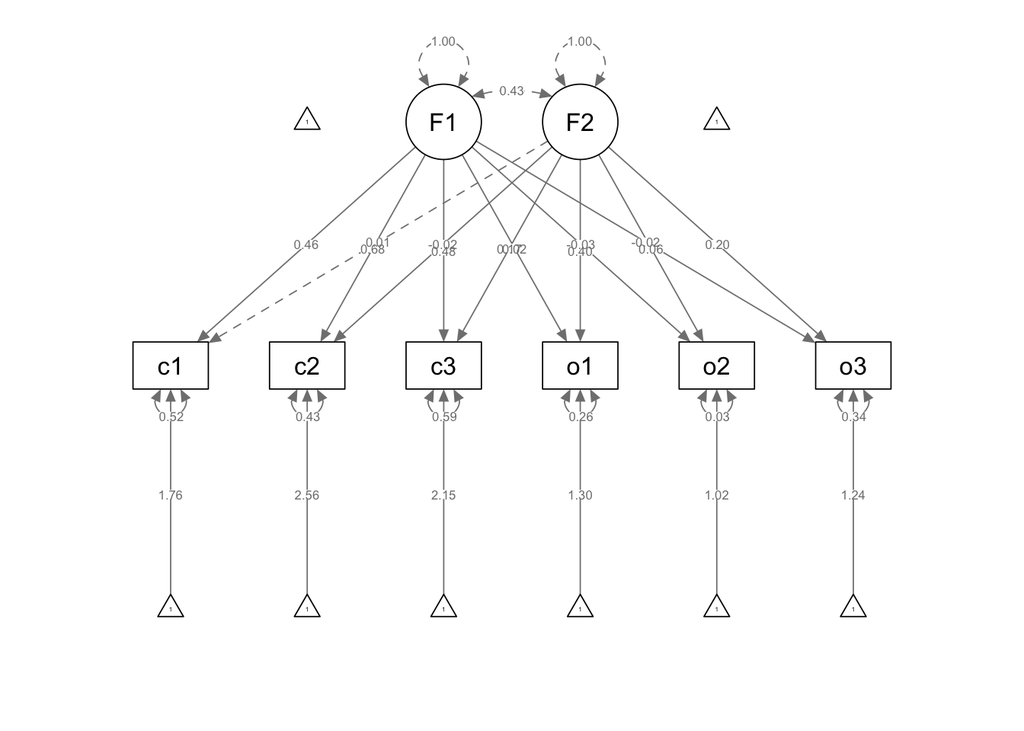

```r
# Another alternative
if (!require("semPlot")) install.packages("semPlot") # install this package first (once)
library(semPlot)
semPaths(fit_2EFA, "par", weighted = FALSE, nCharNodes = 7, shapeMan = "rectangle",
         sizeMan = 8, sizeMan2 = 5)
```

### Exercise 3: CFA

#### 3.1 Use again popular_factor.txt.

**a. Now, run a CFA with 1 factor (‘anti’) and another model with 2-factors (‘covert’ and ‘overt’). In both models, scale by fixing the factor variance, rather than by fixing a loading.**

**Click to show answers**

**One-factor model:**

```r
# CFA

# Specify one-factor CFA model:
model.1CFA <- "
 anti  =~ NA*c1 + c2 + c3 + o1 + o2 + o3
 anti ~~ 1*anti
"

# Fit one-factor CFA model:
fit_1CFA <- cfa(model.1CFA, data=data_pop,
                missing='fiml', fixed.x=F) # Specify FIML

# Model summary:
summary(fit_1CFA)
```

```
## lavaan 0.6-10 ended normally after 28 iterations
##
##   Estimator                                         ML
##   Optimization method                           NLMINB
##   Number of model parameters                        18
##
##                                                   Used       Total
##   Number of observations                          1344        1491
##   Number of missing patterns                         9
##
## Model Test User Model:
##
##   Test statistic                                88.907
##   Degrees of freedom                                 9
##   P-value (Chi-square)                           0.000
##
## Parameter Estimates:
##
##   Standard errors                             Standard
##   Information                                 Observed
##   Observed information based on                Hessian
##
## Latent Variables:
##                    Estimate  Std.Err  z-value  P(>|z|)
##   anti =~
##     c1                0.464    0.028   16.641    0.000
##     c2                0.615    0.032   19.503    0.000
##     c3                0.598    0.032   18.614    0.000
##     o1                0.233    0.022   10.729    0.000
##     o2                0.013    0.006    2.023    0.043
##     o3                0.102    0.021    4.940    0.000
##
## Intercepts:
##                    Estimate  Std.Err  z-value  P(>|z|)
##    .c1                1.765    0.023   75.159    0.000
##    .c2                2.560    0.026  100.248    0.000
##    .c3                2.147    0.026   81.737    0.000
##    .o1                1.299    0.018   73.558    0.000
##    .o2                1.024    0.005  203.841    0.000
##    .o3                1.243    0.017   74.408    0.000
##     anti              0.000
##
## Variances:
##                    Estimate  Std.Err  z-value  P(>|z|)
##     anti              1.000
##    .c1                0.522    0.026   20.115    0.000
##    .c2                0.493    0.033   14.899    0.000
##    .c3                0.565    0.034   16.591    0.000
##    .o1                0.364    0.015   23.657    0.000
##    .o2                0.034    0.001   25.808    0.000
##    .o3                0.363    0.014   25.471    0.000
```

```r
fitMeasures(fit_1CFA, c("chisq", "df", "pvalue", "cfi", "tli", "rmsea","srmr"))
```

```
##  chisq     df pvalue    cfi    tli  rmsea   srmr
## 88.907  9.000  0.000  0.888  0.813  0.081  0.046
```

```r
lavInspect(fit_1CFA)
```

```
## $lambda
##    anti
## c1    1
## c2    2
## c3    3
## o1    4
## o2    5
## o3    6
##
## $theta
##    c1 c2 c3 o1 o2 o3
## c1  7
## c2  0  8
## c3  0  0  9
## o1  0  0  0 10
## o2  0  0  0  0 11
## o3  0  0  0  0  0 12
##
## $psi
##      anti
## anti 0
##
## $nu
##    intrcp
## c1     13
## c2     14
## c3     15
## o1     16
## o2     17
## o3     18
##
## $alpha
##      intrcp
## anti      0
```

**Two-factor model:**

```r
# Specify two-factor CFA model:
model.2CFA <- "
 covert  =~ NA*c1 + c2 + c3
 overt   =~ NA*o1 + o2 + o3
 covert ~~ 1*covert
 overt ~~ 1*overt
"
# Fit two-factor CFA model:
fit_2CFA <- cfa(model.2CFA, data=data_pop,
                missing='fiml', fixed.x=F) # Specify FIML

# Model summary:
summary(fit_2CFA)
```

```
## lavaan 0.6-10 ended normally after 32 iterations
##
##   Estimator                                         ML
##   Optimization method                           NLMINB
##   Number of model parameters                        19
##
##                                                   Used       Total
##   Number of observations                          1344        1491
##   Number of missing patterns                         9
##
## Model Test User Model:
##
##   Test statistic                                25.730
##   Degrees of freedom                                 8
##   P-value (Chi-square)                           0.001
##
## Parameter Estimates:
##
##   Standard errors                             Standard
##   Information                                 Observed
##   Observed information based on                Hessian
##
## Latent Variables:
##                    Estimate  Std.Err  z-value  P(>|z|)
##   covert =~
##     c1                0.466    0.028   16.724    0.000
##     c2                0.630    0.032   19.634    0.000
##     c3                0.593    0.033   18.208    0.000
##   overt =~
##     o1                0.500    0.057    8.797    0.000
##     o2                0.038    0.007    5.512    0.000
##     o3                0.160    0.027    5.960    0.000
##
## Covariances:
##                    Estimate  Std.Err  z-value  P(>|z|)
##   covert ~~
##     overt             0.431    0.055    7.806    0.000
##
## Intercepts:
##                    Estimate  Std.Err  z-value  P(>|z|)
##    .c1                1.765    0.023   75.160    0.000
##    .c2                2.560    0.026  100.241    0.000
##    .c3                2.147    0.026   81.736    0.000
##    .o1                1.300    0.018   73.580    0.000
##    .o2                1.024    0.005  203.848    0.000
##    .o3                1.243    0.017   74.419    0.000
##     covert            0.000
##     overt             0.000
##
## Variances:
##                    Estimate  Std.Err  z-value  P(>|z|)
##     covert            1.000
##     overt             1.000
##    .c1                0.521    0.026   20.096    0.000
##    .c2                0.475    0.034   13.886    0.000
##    .c3                0.570    0.035   16.457    0.000
##    .o1                0.168    0.055    3.033    0.002
##    .o2                0.032    0.001   24.885    0.000
##    .o3                0.348    0.015   23.135    0.000
```

```r
fitMeasures(fit_2CFA, c("chisq", "df", "pvalue", "cfi", "tli", "rmsea","srmr"))
```

```
##  chisq     df pvalue    cfi    tli  rmsea   srmr
## 25.730  8.000  0.001  0.975  0.953  0.041  0.024
```

```r
lavInspect(fit_2CFA)
```

```
## $lambda
##    covert overt
## c1      1     0
## c2      2     0
## c3      3     0
## o1      0     4
## o2      0     5
## o3      0     6
##
## $theta
##    c1 c2 c3 o1 o2 o3
## c1  7
## c2  0  8
## c3  0  0  9
## o1  0  0  0 10
## o2  0  0  0  0 11
## o3  0  0  0  0  0 12
##
## $psi
##        covert overt
## covert  0
## overt  13      0
##
## $nu
##    intrcp
## c1     14
## c2     15
## c3     16
## o1     17
## o2     18
## o3     19
##
## $alpha
##        intrcp
## covert      0
## overt       0
```

**b. Which model is to be preferred? What can you say about the model fit based on the AIC and BIC?**

**Click to show answers**

The Chi-square difference test is significant,implying that the null stating that two factors equal one and the same is rejected. The AIC and BIC for the 2-factor model is lower than for the 1-factor model. Hence, we prefer the 2-factor model.

```r
# Compare the one-factor model to the two-factor model
anova(fit_1CFA, fit_2CFA)
```

```
## Chi-Squared Difference Test
##
##          Df   AIC   BIC  Chisq Chisq diff Df diff Pr(>Chisq)
## fit_2CFA  8 14380 14479 25.730
## fit_1CFA  9 14441 14535 88.907     63.178       1  1.889e-15 ***
## ---
## Signif. codes:  0 '***' 0.001 '**' 0.01 '*' 0.05 '.' 0.1 ' ' 1
```

```r
fitMeasures(fit_1CFA, c("chisq", "df", "pvalue", "cfi", "tli", "rmsea","srmr"))
```

```
##  chisq     df pvalue    cfi    tli  rmsea   srmr
## 88.907  9.000  0.000  0.888  0.813  0.081  0.046
```

```r
fitMeasures(fit_2CFA, c("chisq", "df", "pvalue", "cfi", "tli", "rmsea","srmr"))
```

```
##  chisq     df pvalue    cfi    tli  rmsea   srmr
## 25.730  8.000  0.001  0.975  0.953  0.041  0.024
```

**c. What is the correlation between the two factors?**

**Click to show answers**

The correlation between the two factors

Covariances:

[output not shown]

The correlation between OVERT and COVERT is 0.431 with a standard error of 0.055. So, the proportion of shared variance is 0.4312^2 = 0.186 = 18,6%. Note that in the output one can find this in the ‘standardized results’.

Whether the unstandardized ‘covert ~~ overt’ can be interpreted as a correlation or a covariance, depends on how the latent variable was scaled. If the factor variances are fixed to 1 (i.e., when scaling is done via the factor variances), then the ‘unstandardized’ result reflects the factor correlation. Otherwise they reflect the covariance.

**Plot the results**

Using `lavaanPlot()`:

```r
# Plot
if (!require("lavaanPlot")) install.packages("lavaanPlot") # install this package first (once)
library(lavaanPlot)
lavaanPlot(model = fit_2CFA, node_options = list(shape = "box", fontname = "Helvetica"),
           edge_options = list(color = "grey"), coefs = T, stand = T, covs = T)
```

[interactive chart not shown]

Using `tidySEM()` or `semPlot()`:

[figure not shown]

```r
# Alternative
if (!require("tidySEM")) install.packages("tidySEM") # install this package first (once)
library(tidySEM)
graph_sem(fit_2CFA)
```

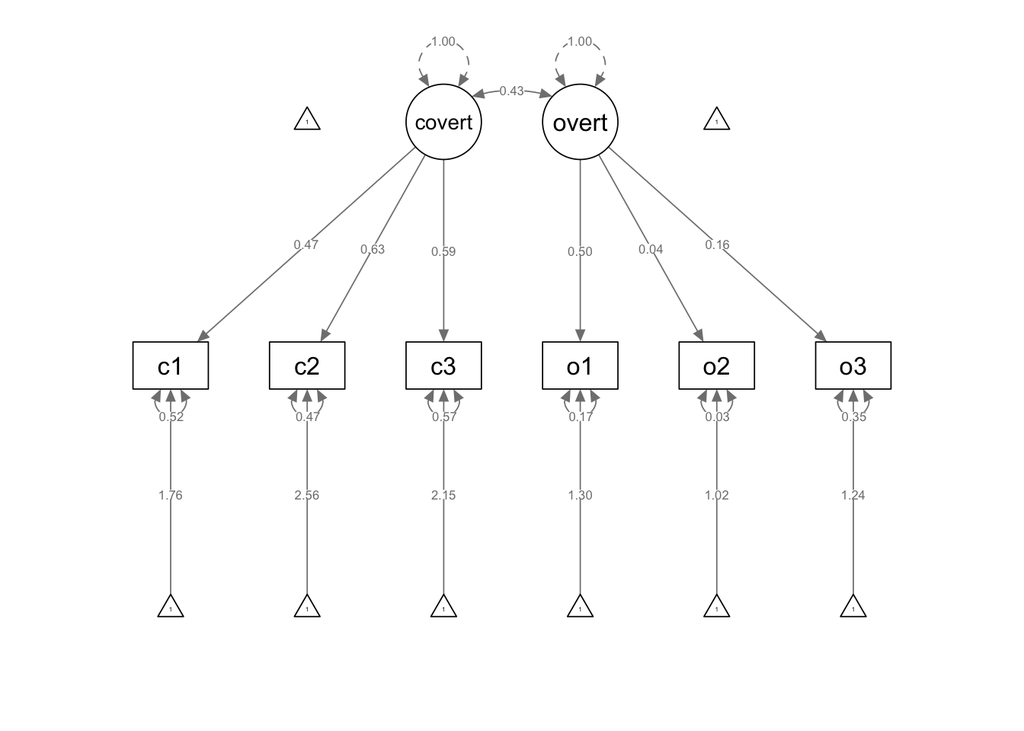

```r
# Another alternative
if (!require("semPlot")) install.packages("semPlot") # install this package first (once)
library(semPlot)
semPaths(fit_2CFA, "par", weighted = FALSE, nCharNodes = 7, shapeMan = "rectangle",
         sizeMan = 8, sizeMan2 = 5)
```

### Helpful notation:

**Helpful notation in factor analysis:**

- =~ indicator, used for latent variable to observed indicator in factor analysis measurement models.
- ~~ covariance
- ~1 intercept or mean (e.g., q01 ~ 1 estimates the mean of variable q01)
- 1* fixes parameter or loading to one
- NA* frees parameter or loading (useful to override default marker method)
- a* labels the parameter ‘a’, used for model constraints

**`lavaan` notation:**

- in regression: ~ means is regressed on
- for (residual) (co)variance: ~~ means is correlated with
- intercept: ~ 1 means intercept
- latent variable definition: =~ means is measured by

**Note:**

- ~ predict, used for regression of observed outcome to observed predictors
- =~ indicator, used for latent variable to observed indicator in factor analysis measurement models

**General `lavaan` specification:**

**Regression:**

- y1 + y2 ~ f1 + f2 + x1 + x2
- f1 ~ f2 + f3
- 2 ~ f3 + x1 + x2

**Latent variable definitions:**

- f1 =~ y1 + y2 + y3
- f2 =~ y4 + y5 + y6
- f3 =~ y7 + y8 + y9 + y10

**Variances and covariances:**

- y1 ~~ y1
- y ~~ y2
- f1 ~~ f2

**Intercepts:**

- y1 ~ 1
- f1 ~ 1